# L4P2: Regressão romântica

Hugo Gabriel

Nesta análise estamos utilizando dados de encontros relâmpago realizados envolvendo 310 jovens norte-americanos. Mais detalhes sobre os dados podem ser encontrados [aqui](https://github.com/hugogbs/ciencia-de-dados-1/tree/master/5-regressao/speed-dating).

```r
date_data <- read_csv("speed-dating2.csv")
```

Os dados contam com 4918 observações e 44 variáveis.

Com base na descrição dos dados, foram selecionadas as seguintes colunas:

- **Atraente** : quão atraente p1 achou p2
- **Sincera(o)** : quão sincero p1 achou p2
- **Inteligente** : quão inteligente p1 achou p2
- **Divertido(a)** : quão divertido p1 achou p2
- **Ambicioso(a)** : quão ambicioso p1 achou p2
- **Compartilha Interesses** : quanto p1 achou que compartilha interesses e hobbies com p2
- **Gostei** : no geral, quanto p1 gostou de p2

para descrever o **Match**.

```r
date_data <- date_data %>%
    mutate(dec = as.factor(dec)) %>%
    mutate(
      Match = dec,
      Atraente = attr,
      `Sincera(o)` = sinc,
      Inteligente = intel,
      `Divertido(a)` = fun,
      `Ambicioso(a)` = amb,
      `Compartilha Interesses` = shar,
      Gostei = like
    ) %>%
    select(Match, Atraente, `Sincera(o)`, Inteligente, `Divertido(a)`, `Ambicioso(a)`, `Compartilha Interesses`, Gostei) %>%
    na.omit()
```

Após a seleção das variáveis e a remoção de *NA*, nossos dados tem 4123 observações e 8 variáveis.

Nestes dados tempos as seguinte proporção de Matchs:

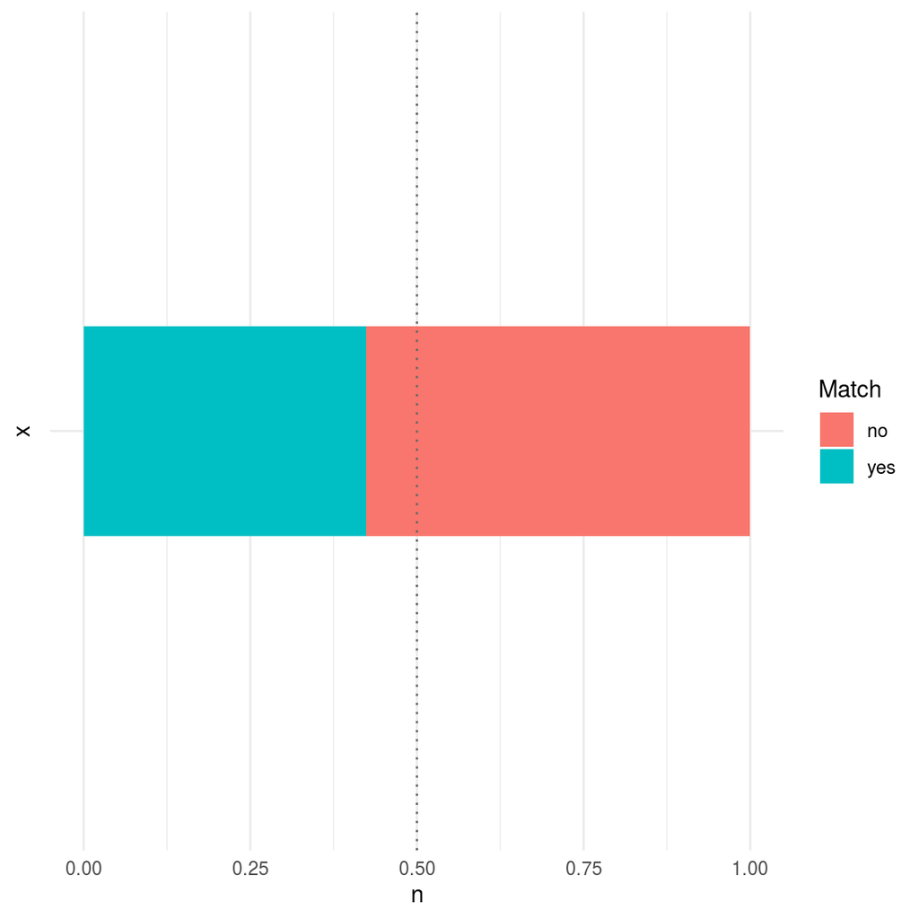

```r
date_data %>%
  group_by(Match) %>%
  count() %>%
  arrange(-n) %>%
  ggplot(aes(x="", fill=Match, y=n)) +
  geom_bar(stat="identity", position = "fill", width=.3) +
  geom_hline(aes(yintercept=0.5), linetype = 3, color="#696969") +
  coord_flip() +
  theme_minimal()
```

Nossas variáveis tem a seguinte distribuição em relação à variável resposta:

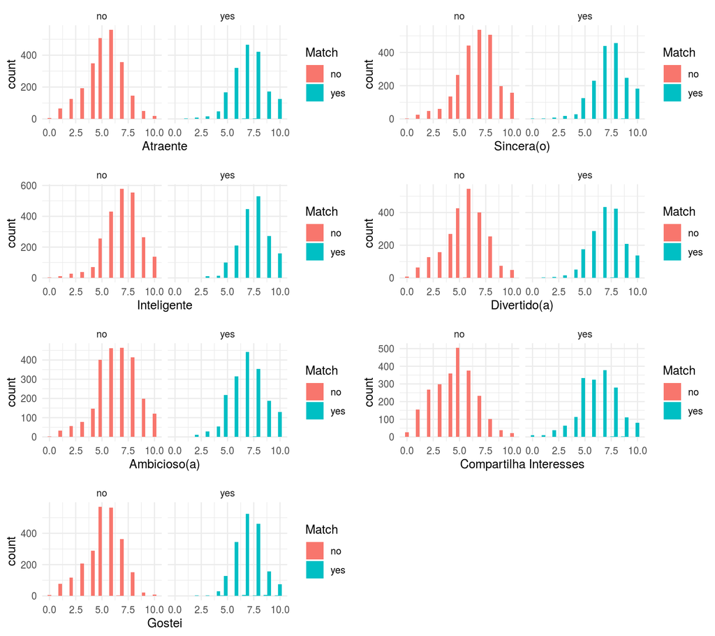

```r
plot_att <- date_data %>%
  ggplot() +
  geom_histogram(aes(x=Atraente, fill=Match)) +
  facet_wrap(~Match) +
  theme(legend.position = "none") +
  theme_minimal()

plot_sinc <- date_data %>%
  ggplot() +
  geom_histogram(aes(x=`Sincera(o)`, fill=Match)) +
  facet_wrap(~Match) +
  theme(legend.position = "none") +
  theme_minimal()

plot_intel <- date_data %>%
  ggplot() +
  geom_histogram(aes(x=Inteligente, fill=Match)) +
  facet_wrap(~Match) +
  theme(legend.position = "none") +
  theme_minimal()

plot_div <- date_data %>%
  ggplot() +
  geom_histogram(aes(x=`Divertido(a)`, fill=Match)) +
  facet_wrap(~Match) +
  theme(legend.position = "none") +
  theme_minimal()

plot_amb <- date_data %>%
  ggplot() +
  geom_histogram(aes(x=`Ambicioso(a)`, fill=Match)) +
  facet_wrap(~Match) +
  theme(legend.position = "none") +
  theme_minimal()

plot_comp <- date_data %>%
  ggplot() +
  geom_histogram(aes(x=`Compartilha Interesses`, fill=Match)) +
  facet_wrap(~Match) +
  theme(legend.position = "none") +
  theme_minimal()

plot_gostei <- date_data %>%
  ggplot() +
  geom_histogram(aes(x=Gostei, fill=Match)) +
  facet_wrap(~Match) +
  theme(legend.position = "none") +
  theme_minimal()

grid.arrange(plot_att, plot_sinc, plot_intel, plot_div, plot_amb, plot_comp, plot_gostei, ncol=2)
```

Utilizaremos um modelo de [regressão logística](https://pt.wikipedia.org/wiki/Regress%C3%A3o_log%C3%ADstica) para determinar o **odds** de uma pessoa dar **Match** com a outra, com base nas variáveis escolhidas.

O odds é calculado como: $p(Match)/(1 - p(Match))$

```r
model <- glm(Match ~ Atraente + `Sincera(o)` + Inteligente + `Divertido(a)` + `Ambicioso(a)` + `Compartilha Interesses` + Gostei, data = date_data, family = 'binomial')
```

```r
model_tidy <- tidy(model, conf.int = TRUE, conf.level = .95, exp=TRUE) %>%
    select(-c(std.error, p.value))
```

De acordo com o modelo gerado, a fórmula que descreve o odds é:

> Odds = 1.94<sup>Gostei</sup> + 1.5<sup>Atraente</sup> + 1.22<sup>‘Compartilha Interesses’</sup> + 1.14<sup>Divertido(a)</sup> + 0.94<sup>Inteligente</sup> + 0.81<sup>Ambicioso(a)</sup> + 0.81<sup>Sincera(o)</sup> + 0.003

A visualização abaixo nos mostra a estimativa e o intervalo de confiança (95%) de cada variável.

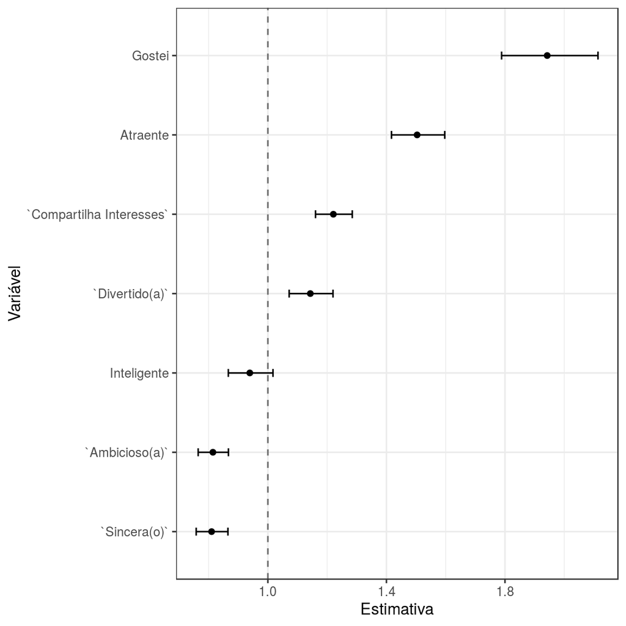

```r
model_tidy %>%
    filter(term != "(Intercept)") %>%
    ggplot(aes(x=reorder(term, estimate), y=estimate)) +
    geom_point() +
    geom_errorbar(aes(ymin=conf.low, ymax=conf.high),  width=.1) +
    geom_hline(aes(yintercept = 1), linetype=2, color="#696969") +
    theme_bw() +
    labs(x="Variável", y="Estimativa") +
    coord_flip()
```

Com o gráfico podemos perceber facilmente quais variáveis têm mais infuência sobre o odds, a exemplo de **Gostei** que tem o maior “peso”.

Já as variáveis **Sincera(o)** e **Ambicioso(a)** têm influência negativa, ou seja, a medida que elas crescem o odds cai.

O coeficiente de McFadden do nosso modelo é **0.314**.

### Conclusão

Regressão logística foi utilizada para analisar se o Atraente, Sincera(o), Inteligente, `Divertido(a)`, `Ambicioso(a)`, `Compartilha Interesses` e Gostei têm uma associação significativa com o Match. Os resultados da regressão indicam que um modelo com os 7 preditores no formato:

**Odds = 1.94<sup>Gostei</sup> + 1.5<sup>Atraente</sup> + 1.22<sup>‘Compartilha Interesses’</sup> + 1.14<sup>Divertido(a)</sup> + 0.94<sup>Inteligente</sup> + 0.81<sup>Ambicioso(a)</sup> + 0.81<sup>Sincera(o)</sup> + 0.003**

explica **31.4%** da variância da variável de resposta.

Ainda quanto ao Odds, observamos que considerando IC’s com 95% de confiança:

- Gostei, tem uma relação positiva forte (b<sub>Gostei</sub> = 1.94, [1.79; 2.11]);
- Atraente, tem uma relação positiva forte (b<sub>Atraente</sub> = 1.5, [1.42; 1.60]);
- Compartilha Interesses, tem uma relação positiva mediana (b<sub>‘Compartilha Interesses’</sub> = 1.22, [1.16; 1.28]);
- Divertido(a), tem uma relação positiva fraca (b<sub>Divertido(a)</sub> = 1.14, [1.07; 1.22]);
- Inteligente, tem uma relação que pode ou não influir (b<sub>Inteligente</sub> = 0.94, [0.87; 1.02])
- Ambicioso(a), tem uma relação negativa fraca (b<sub>Ambicioso(a)</sub> = 0.81, [0.76; 0.87])
- Sincera(o), tem uma relação negativa fraca (b<sub>Sincera(o)</sub> = 0.81, [0.76; 0.87])